# COMM 7800-001: Data Analysis in Communication

[Sara K. Yeo](https://faculty.utah.edu/~sarakyeo) | Associate Professor | sara.yeo@utah.edu | [@sarakyeo](https://twitter.com/sarakyeo)  
Th 2 - 5 pm | GC 4660 | Fall 2021 | University of Utah

> “One of the beautiful things about science is that it allows us to bumble along, getting it wrong time after time, and feel perfectly fine as long as we learn something each time. No doubt, this can be difficult for students who are accustomed to getting the answers right. No doubt, reasonable levels of confidence and emotional resilience help […] The more comfortable we become with being stupid, the deeper we will wade into the unknown and the more likely we are to make big discoveries.” (Schwartz, 2008)

# Course Description and Objectives

This graduate seminar is an introductory course in quantitative data analysis for communication-related topics. The main objectives of this course are:

1. To offer a theoretical perspective on quantitative social science research with a focus on surveys and experiments in communication.
2. To familiarize you with data analysis using two software packages, R and IBM SPSS Statistics.
3. To stimulate ideas for original research and help you conduct data analysis for your own research projects.

This seminar is set up as a lab course. I will provide context and some reading materials, but much of the course will be spent analyzing data, trying to make sense of output, and linking data analysis to research questions and hypotheses. We will also have working labs at the end of the semester for you to analyze your own data.

# Required Readings

For each week, I have compiled a non-exhaustive set of readings. I will post the weekly reading list on Canvas. If PDFs are not available through the Marriott Library resources, the files will be posted on Canvas.

You are expected to complete these readings before the start of each meeting. These readings are intended as a point-of-entry into the week’s content. They may also be useful if you are trying to compile a reading list for your preliminary examinations.

# Computer Software

You will need Microsoft Office (Word, Excel, PowerPoint) and software for data analysis ([R](https://www.r-project.org/), IBM SPSS Statistics). We will set up R and IBM SPSS Statistics during the course–you do not have to have them ready for the first day of class.

Additionally, access to a text-editor (e.g., Wordpad, TextEdit, Notepad++, Atom) and Adobe Acrobat (free for UofU students) is recommended.

You will need access to [Canvas](https://utah.instructure.com/). I expect you to check the course website on Canvas regularly. Announcements, assignments, readings, discussions, etc., will be posted there. You should be familiar with and comfortable using Canvas and Zoom. If you need help with Canvas, visit the [Canvas Getting Started Guide for Students](https://community.canvaslms.com/docs/DOC-10701).

# Course Requirements

Your grade in this course will be based on the following:

- Lab assignments (30%)
- Discussion leadership (30%)
- Final presentation (30%)
- Participation (10%)

## Lab Assignments

There will be four assignments in this course. These assignments will be shared at the beginning of the semester. Each assignment build skills in data analysis. You may work on these assignments on your own time but must submit all the assignments by **Week 13**. Detailed information will be provided in the assignment.

- [GA.1: Working with Statistical Software](https://sarakyeo.github.io/COMM-7800/GA/GA.1.html)
- [GA.2: Data Management with SPSS and R](https://sarakyeo.github.io/COMM-7800/GA/GA.2.html)
- [GA.3: Practice Data Analysis](https://sarakyeo.github.io/COMM-7800/GA/GA.3.html)
- [GA.4: Practice Data Analysis](https://sarakyeo.github.io/COMM-7800/GA/GA.4.html)

## Discussion Leadership

You will serve as discussant for **3 class meetings**. We will sign up in Week 1.

- You will lead one (1) discussion in Weeks 2 or 3 (theoretical/introductory topics).
- You will lead two (2) discussions in Weeks 6 through 11 (methodological topics).

**Discussion leadership in Weeks 2 or 3.** Weeks 2 and 3 are designed to introduce the theoretical underpinnings of quantitative social science research. For these weeks, discussion leadership includes:

- Making sure that we have a clear understanding of all relevant definitions and assumptions.
- Giving a brief team presentation of the week’s topic and preparing questions to facilitate discussion. Handouts and brief excerpts from outside sources are acceptable and encouraged.
- Guiding our debate of the strengths and weaknesses of the readings and encouraging evidence-driven debate. This is also a good opportunity to raise any questions about the topic.
- You are encouraged to develop your critical and analytic skills by engaging with the material. Therefore, I encourage you to articulate your arguments based on evidence, not personal experiences or feelings.

**Discussion leadership in Weeks 6 through 11.** Your discussion leadership of Weeks 6 through 11 should focus on the application of the week’s data analysis method. How can or is this method used to address research questions and hypotheses in communication science? You are welcome to use any data set with which you are familiar for your presentation of this week–keep in mind that you will be presenting as a team and all team members should be familiar with the data sets used for presentation. If you are unable to access data, I am happy to furnish some data for your presentation.

For a methods presentation, please include:

- A 1-2 page handout with a quick overview of the analytic tool you are presenting.
- The R code and SPSS syntax that you present during our meeting.

Please upload materials for the methods presentation to Canvas **at least 48 hours before the meeting time during which you are scheduled to present**.

## Final Project/Presentation

What you have learned throughout the course of the semester will culminate in a research presentation based on quantitative data analysis. Ideally, this will be analysis of data from a project on which you are currently working.

If you do not have access to data, I am happy to share some survey data on perceptions around enhanced geothermal systems (EGS) that is part of an on-going collaboration with the [Utah FORGE](https://utahforge.com) project. You are also welcome to use publicly available data (e.g., General Social Survey).

Your presentation should include:

- Outlining the research problem and its relevance for a specific discipline.
- Translating the problem into research questions and testable hypotheses.
- A discussion of the measures used in your project and justification for measures and analytic procedures.
- An analytic answer addressing your stated research questions and hypotheses.
- Appendices (as PDF files, not included in your presentation) or additional materials that show your analytic procedures (i.e., SPSS syntax or R code).

You will present a **project prospectus in Week 6**. Your prospectus should include all the components of your final presentation or a plan for accomplishing each component.

## Participation

This is a graduate-level seminar and learning occurs through discussion and debate. To this end, your attendance at virtual meetings and involvement (both synchronous and asynchronous) are required. To make this fun, you must be prepared to discuss course content. It is not enough to simply attend meetings. You are expected to actively participate in discussion of the readings and critically analyze their contents.

There is a significant amount of reading in this course. You are required to complete assigned tasks, on time and with care. Because participation is integral to this course, you are allowed **one unexcused absence without penalty**. Each subsequent absence will affect your final grade.

For an absence to be excused, there must be a valid reason and I must be notified in advance. Tardiness will count as unexcused absences. More information on the University attendance policy can be found [here](https://regulations.utah.edu/academics/6-100.php).

# Course Grading

Information on calculating your GPA can be found [here](https://advising.utah.edu/academic-standards/gpa-calculator.php/academic-standards/gpa-calculator.php).

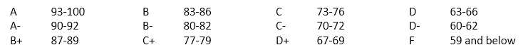

# Course Policies

## Course Civility

By enrolling in this course, you agree to (i) respect all members of the course; (ii) pay attention and participate in all classes and activities; and (iii) avoid unnecessary disruption during class meetings (e.g., text messaging, checking social media, doing work for other classes). This list represents the minimal standards to make the classroom a productive learning space for all. Your final grade may be affected each time you engage in disruptive and/or disrespectful behaviors.

Communication allows us to engage with others and broaden our perspectives. How we discuss concepts, in the physical or virtual classroom, is part of that process. Our diverse perspectives and experiences will inform and enhance those discussions. Each member of the class is expected to foster a respectful, generous, and supportive (online) environment that makes space for productive difference and reasoned debate. Spirited discussion is encouraged. However, incivility is a different story entirely. Here is the basic (n)etiquette that will be expected in the course:

- Always address your classmates by name. There is a human being on the other side of the screen/room who also has struggles, doubts, and bad days.
- Disagreement is encouraged! Approach differences in a manner that seeks clarity and better understanding by asking productive questions and by providing counterarguments that are supported with evidence.
- Anytime you have a strong emotional reaction to something, pause before responding. Always seek to provide an argument that is supported by **credible evidence** based on the theories we discuss in this course.

## Email Policy

**Use your University email account to contact me; I will not respond to emails originating from a non-University account (e.g., Google, Yahoo, etc.)**. Using a non-University account runs the risk of your message being diverted to Spam and your message may not reach me in a timely fashion, if at all.

Emails should be written clearly and professionally, using appropriate salutations (e.g., Dr. or Prof. Yeo) with correct spelling and grammar. **Emails that do not conform to these rules will not receive a response.**

If you need to contact me, please send a message from your University of Utah email account to sara.yeo@utah.edu.

## Academic Misconduct

**Academic misconduct will be punished to the fullest extent possible**. You are responsible for understanding what constitutes academic misconduct (see [Policy 6-400](http://regulations.utah.edu/academics/6-400.php)). Anyone found guilty of academic misconduct should expect to fail this course. In addition, academic misconduct may result in other penalties deemed appropriate by the university. Your rights and responsibilities are outlined in Policy 6-400, the Code of Student Rights and Responsibilities. You are responsible for obeying [Policy 6-400](http://regulations.utah.edu/academics/6-400.php). Ignorance of the policy is not an excuse.

## Emergency Plan

In the event of a University-wide emergency which prevents us from meeting, you should continue to stay current with our schedule as posted in this syllabus and to attend to the course website on Canvas. Information about the status of assignments and other course work due during this period will be addressed on Canvas and by way of email. **It is critical that you check your University email account and Canvas frequently**.

## Accommodations

Curriculum accommodations take two forms—scheduling and content accommodations. **There will be no content accommodations in this course**. The material has been selected for its pedagogical value in relation to the concepts we are engaging. It is your responsibility to review the course materials to be sure that this is a course you wish to take. More information on the University’s accommodation policy can be found in [Policy 6-100](https://regulations.utah.edu/academics/6-100.php).

# University Policies

## COVID-19

**COVID-19.** This is an in-person course; you will be expected to attend weekly classes in person. To protect yourself and those you care about, the University recommends that you:

- **Get a COVID-19 vaccination** if you have not already done so.
- **Get weekly asymptomatic coronavirus tests** if you are not vaccinated (don’t worry, no nasal swabs). For more information or to schedule an asymptomatic coronavirus test, visit [alert.utah.edu/covid/testing](https://alert.utah.edu/covid/testing/).
- **Wear a facemask properly while indoors**.

If you test positive for COVID-19, you must submit a report at coronavirus.utah.edu. For more information about how the University is handling the coronavirus pandemic, visit coronavirus.utah.edu.

## ADA

**The Americans with Disabilities Act.** The University of Utah seeks to provide equal access to its programs, services, and activities for people with disabilities. If you will need accommodations in this class, reasonable prior notice needs to be given to the Center for Disability Services, 162 Olpin Union Building, (801) 581-5020. CDS will work with you and the instructor to arrange accommodations. All written information in this course can be made available in an alternative format with prior notification to the [Center for Disability Services](https://disability.utah.edu/).

## Safety

**University Safety Statement.** The University of Utah values the safety of all campus community members. To report suspicious activity or to request a courtesy escort, call campus police at 801-585-COPS (801-585-2677). You will receive important emergency alerts and safety messages regarding campus safety via text message. For more information regarding safety and to view available training resources, including helpful videos, visit [safeu.utah.edu](http://safeu.utah.edu/).

**Addressing Sexual Misconduct.** Title IX makes it clear that violence and harassment based on sex and gender (includes sexual orientation and gender identity/expression) is a civil rights offense subject to the same kinds of accountability and the same kinds of support applied to offenses against other protected categories such as race, national origin, color, religion, age, status as a person with a disability, veteran’s status or genetic information. If you or someone you know has been harassed or assaulted, you are encouraged to report it to the Title IX Coordinator in the Office of Equal Opportunity and Affirmative Action, 135 Park Building, 801-581-8365, or the Office of the Dean of Students, 270 Union Building, 801-581-7066. For support and confidential consultation, contact the Center for Student Wellness, 426 SSB, 801-581-7776. To report to the police, contact the Department of Public Safety, 801-585-2677 (COPS).

Responsible employees and campus security authorities (CSAs) have different obligations. Responsible employees are defined by Title IX and CSAs are defined under the Clery Act. Though certain people/positions may be both, the concepts and requirements are different. On our campus, responsible employees are required to report any information about possible sexual misconduct or discrimination to the OEO/AA. CSAs are required to report crimes that occurred on campus to campus police.

Responsible employees are university employees, including students in paid leadership positions, who are required to report sexual misconduct to the Office of Equal Opportunity and Affirmative Action per university regulations. Examples of responsible employees include:

- Professors and other faculty
- Administration and staff (non-mental health)
- Resident advisors
- Student employees
- Campus police or campus security officials
- Athletic coaches/assistants

Campus security authorities are university employees who have significant responsibility for student and campus activities, including but not limited to student housing, student discipline and campus judicial proceedings and are designated to receive and report criminal incidents to the University of Utah Police Department.

## Undocumented Student Support

**Undocumented Student Support Statement.** Immigration is a complex phenomenon with broad impact—those who are directly affected by it, as well as those who are indirectly affected by their relationships with family members, friends, and loved ones. If your immigration status presents obstacles to engaging in specific activities or fulfilling specific course criteria, confidential arrangements may be requested from the Dream Center. Arrangements with the Dream Center will not jeopardize your student status, your financial aid, or any other part of your residence. The Dream Center offers a wide range of resources to support undocumented students (with and without DACA) as well as students from mixed-status families. To learn more, please contact the Dream Center at 801-213-3697 or visit [dream.utah.edu](http://dream.utah.edu/).

# Course Schedule

## Week 1 (26-Aug)

> Course introduction

## Week 2 (2-Sep)

> Scientific approaches, social science, and the importance of stupidity

**Discussants:** Trevor Smith, Alexis Vega

**Readings:**

- Chalmers, A. F. (2013). Introduction. In *What Is This Thing Called Science?* (pp. xix-xxi). Hackett Publishing Company, Incorporated.
- Chalmers, A. F. (2013). Introducing Falsificationism. In *What Is This Thing Called Science?* (pp. 55–68). Hackett Publishing Company, Incorporated.
- Donsbach, W. (2006). The identity of communication research. *Journal of Communication, 56(3)*, 437–448. https://doi.org/10.1111/j.1460-2466.2006.00294.x
- Schwartz, M. A. (2008). The importance of stupidity in scientific research. *Journal of Cell Science, 121*(11), 1771–1771. https://doi.org/10.1242/jcs.033340

## Week 3 (9-Sep)

> From explication to measurement: Empirical social science research

**Discussants:** Dallin Adams, Yi Liao, Henry Allen

**Readings:**

- Eveland, Jr., W. P. (1997). Interactions and nonlinearity in mass communication: Connecting theory and methodology. *Journalism & Mass Communication Quarterly, 74*(2), 400–416. https://doi.org/10.1177/107769909707400211
- Chaffee, S. H. (1991). *Explication*. SAGE Publications, Inc.
- McLeod, J. M., & Pan, Z. (2005). Concept Explication and Theory Construction. In S. Dunwoody, L. B. Becker, D. M. McLeod, & G. M. Kosicki (Eds.), *The Evolution of Key Mass Communication Concepts* (pp. 13–76). Hampton Press, Inc.

## Week 4 (16-Sep)

> Getting familiar with IBM SPSS Statistics and R

**Discussant:** Sara Yeo

**Readings:**

- Yeo, S. K. (2021). *Introduction to SPSS*. COMM 7800: Data Analysis in Communication.
- Yeo, S. K., & Sun, Y. (2021). [COMM 3710: Getting Started with R](https://sarakyeo.github.io/COMM-3710-bookdown/docs/index.html) (Chapters 1 and 2).

## Week 5 (23-Sep)

> Data management tutorial

**Discussant:** Sara Yeo

**Discussion Topics:**

- Basics of SPSS and R
- Syntax vs. GUI
- Setting preferences in SPSS and R
- Reading data into SPSS and R
- Types of data and levels of measurement
- Missing data
- Descriptive statistics in a dataset
- Recoding variables

## Week 6 (30-Sep)

> Reliability and validity

**Discussants:** Henry Allen, Dallin Adams

**Readings:**

- Carmines, E. G., & Zeller, R. A. (1979). *Reliability and Validity Assessment*. Newbury Park, CA: SAGE Publications.
- Binder, A. R., Cacciatore, M. A., Scheufele, D. A., Shaw, B. R., & Corley, E. A. (2012). Measuring risk/benefit perceptions of emerging technologies and their potential impact on communication of public opinion toward science. *Public Understanding of Science, 21*(7), 830–847. https://doi.org/10.1177/0963662510390159

*Project prospectus due by 11:59 pm today.

## Week 7 (7-Oct)

> Analysis of variance

**Discussants:** Trevor Smith, Dallin Adams

**Readings:**

- Chatelain, A. M. (2015). The effect of academics’ dress and gender on student perceptions of instructor approachability and likeability. *Journal of Higher Education Policy & Management, 37*(4), 413–423. https://doi.org/10.1080/1360080X.2015.1056598
- Wrench, J. S., Thomas-Maddox, C., Richmond, V. P., & McCroskey, J. C. (2019). Independent Samples t-Tests. In *Quantitative Research Methods for Communication: A Hands-On Approach* (4th ed., pp. 471–490). Oxford University Press.
- Wrench, J. S., Thomas-Maddox, C., Richmond, V. P., & McCroskey, J. C. (2019). One-Way Analysis of Variance. In *Quantitative Research Methods for Communication: A Hands-On Approach* (4th ed., pp. 492–515). Oxford University Press.

## Week 8 (14-Oct)

> FALL BREAK (no class)

## Week 9 (21-Oct)

> Introduction to regression

**Discussants:** Yi Liao, Alexis Vega

**Readings:**

- Wrench, J. S., Thomas-Maddox, C., Richmond, V. P., & McCroskey, J. C. (2019). Regression. In *Quantitative Research Methods for Communication: A Hands-On Approach* (4th ed., pp. 539–559). Oxford University Press.
- Akin, H., Cacciatore, M. A., Yeo, S. K., Brossard, D., Scheufele, D. A., & Xenos, M. A. (2021). Publics’ support for novel and established science issues linked to perceived knowledge and deference to science. *International Journal of Public Opinion Research, 33*(2), 422–431. https://doi.org/10.1093/ijpor/edaa010

**References:**

- Achen, C. H. (1982). *Interpreting and Using Regression*. SAGE Publications, Inc.

## Week 10 (28-Oct)

> Interactions in regression: Moderation

**Discussants:** Alexis Vega, Trevor Smith

**Readings:**

- Cacciatore, M. A., Becker, A. B., Anderson, A. A., & Yeo, S. K. (2020). Laughing with science: The influence of audience approval on engagement. *Science Communication, 42*(2), 195–217. https://doi.org/10.1177/1075547020910749
- Frazier, P. A., Tix, A. P., & Barron, K. E. (2004a). Testing moderator and mediator effects in counseling psychology research. *Journal of Counseling Psychology, 51*(1), 115–134. https://doi.org/10.1037/0022-0167.51.1.115
- Spiller, S. A., Fitzsimons, G. J., Lynch, J. G., & Mcclelland, G. H. (2013). Spotlights, floodlights, and the magic number zero: Simple effects tests in moderated regression. *Journal of Marketing Research, 50*(2), 277–288. https://doi.org/10.1509/jmr.12.0420

## Week 11 (4-Nov)

> Mediation analysis: Introduction to PROCESS

**Discussants:** Yi Liao, Henry Allen

**Readings:**

- Hayes, A. F. (2009). Beyond Baron and Kenny: Statistical mediation analysis in the new millennium. *Communication Monographs, 76*(4), 408–420. https://doi.org/10.1080/03637750903310360
- Yeo, S. K., Anderson, A. A., Becker, A. B., & Cacciatore, M. A. (2020). Scientists as comedians: The effects of humor on perceptions of scientists and scientific messages. *Public Understanding of Science, 29*(4), 408–418. https://doi.org/10.1177/0963662520915359

## Week 12 (11-Nov)

> Manuscript preparation and publishing (Discussant: Dr. Sara Yeo)

**Readings:**

- Anonymous. (2008, July 19). Great minds think (too much) alike. The Economist, 388(8589), 94. The Economist Historical Archive.
- Campbell, P. (2008). Escape from the impact factor. Ethics in Science and Environmental Politics, 8(1), 5–7. https://doi.org/10.3354/esep00078

## Week 13 (18-Nov)

> Working lab

*All lab assignments (GA.1 through GA.4) due by 11:59 pm today.

## Week 14 (25-Nov)

> THANKSGIVING (no class)

## Week 15 (2-Dec)

> Working lab

## Week 16 (9-Dec)

> Final presentations